# Pulmonic stenosis survival stats

Alex German

2026-09-01

# Check working directory

```r
getwd()
```

```
## [1] "/Users/alexg/Documents/R files/pulmonic_stenosis"
```

# Load packages

```r
library(readxl)
library(psych)
library(dlookr)
library(vtable)
library(dplyr)
library(tidyr)
library(purrr)
library(reshape)
library(vioplot)

library(tidyverse)
library(pammtools)
library(splines2)
library(posterior)
library(ggplot2)
library(rethinking)
library(survminer)
library(survival)
library(cowplot)
library(rstanarm)
library(bayestestR)
library(brms)
library(tidybayes)
library(bayesplot)
```

# Load data

```r
df <- read_xlsx("pulmonic_stenosis_it_bias.xlsx", col_types = c("text", "text",
                               "text", "numeric", "text", "numeric", "text",
                               "numeric", "numeric", "numeric", "numeric",
                               "numeric", "numeric", "text",
                               "numeric", "numeric", "numeric", "numeric",
                               "numeric", "numeric", "numeric",  "numeric", "text",
                               "numeric",  "numeric", "text",
                                "numeric", "numeric", "numeric",
                               "numeric", "numeric",
                               "numeric", "numeric", "numeric",
                               "numeric", "text", "numeric", "numeric",
                               "numeric", "numeric", "numeric",
                               "numeric", "numeric", "numeric"))

df <- as.data.frame(df)
```

## make ‘centre’ a factor variable

```r
df$centre <- factor(df$centre)
```

## counts and percentages of ‘status’

```r
df %>%
  count(status) %>%
  mutate(percent = 100 * n / sum(n))
```

```
##   status   n  percent
## 1      0 157 79.29293
## 2      1  41 20.70707
```

## Breakdown by ‘type’

```r
df %>%
  count(type) %>%
  mutate(percent = 100 * n / sum(n))
```

```
##           type  n  percent
## 1            a 75 37.87879
## 2            b 38 19.19192
## 3 intermediate 85 42.92929
```

# INITIAL DATA PLOTTING AND EXPLORATION

## Check characteristics of df

```r
dim(df) # will tell you how many rows and columns the dataset has
```

```
## [1] 198  44
```

```r
class(df) # will tell you what data structure has the dataset been assigned
```

```
## [1] "data.frame"
```

## Explore the dataset to understand its structure.

```r
head(df)
```

```
##         id dog centre age sex weight dead_alive status time
## 1 78572362  d1      p  17   F   12.9       Dead      0  598
## 2 78572362  d1      p  17   F   12.9       Dead      1  598
## 3 77923096  d2      p   9   F    4.2       Dead      1   75
## 4 77945230  d3      p  12   M    5.2        N/a      0    0
## 5 75323610  d4      p  44   M   16.6      Alive      0 1786
## 6 69047018  d5      p  46   M    9.7        N/a      0 1079
##   diagnosis_to_procedure procedure_to_time tstart tstop         type
## 1                    118               480      0   118 intermediate
## 2                    118               480    118   598 intermediate
## 3                     NA                NA      0    75 intermediate
## 4                     NA                NA      0     1            a
## 5                     NA                NA      0  1786 intermediate
## 6                     NA                NA      0  1079 intermediate
##   concurrent_congenital clinical_signs chf arrhythmias atenolol atenolol_pre
```

[output cut: 34 more lines]

### standardise numeric predictors

```r
df$s_age <- standardize(df$age)
df$s_weight <- standardize(df$weight)
df$s_vmax <- standardize(df$vmax)
df$s_pv_max_pg <- standardize(df$pv_max_pg)
df$s_vtiao_vtipv <- standardize(df$vtiao_vtipv)
df$s_vmaxav_vmaxpv <- standardize(df$vmaxav_vmaxpv)
df$s_edao_pvtrunk <- standardize(df$edao_pvtrunk)
df$s_ed_rvfw <- standardize(df$ed_rvfw)
df$s_ra_max_diam <- standardize(df$ra_max_diam)
df$s_tapse <- standardize(df$tapse)
df$s_ed_rvfw_n <- standardize(df$ed_rvfw_n)
df$s_tapse_n <- standardize(df$tapse_n)
df$s_ra_max_diam_n <- standardize(df$ra_max_diam_n)
```

### make categorical vectors into factors

```r
df$concurrent_congenital <- factor(df$concurrent_congenital)
df$chf <- factor(df$chf)
df$arrhythmias <- factor(df$arrhythmias)
df$atenolol <- factor(df$atenolol)
df$surgery <- factor(df$surgery)
df$proc_type <- factor(df$proc_type)
df$complications <- factor(df$complications)
```

### make balloon type a factor variable with low pressure as the reference category

```r
df$balloon_type <- factor(df$balloon_type, levels = c("low_pressure", "high_pressure"))
```

### Create binary variable from edao_pvtrunk

```r
df$annular_hypoplasia <- ifelse(df$edao_pvtrunk > 1.2, "yes", "no")
```

## Create df of dogs undergoing surgery

```r
df_surg <- df |>
  filter(surgery == 1)
```

## Create df of dogs undergoing balloon valvuloplasty

```r
df_balloon <- df |>
  filter(balloon == 1)
```

# 1. Get summary stats for numeric data

```r
numeric_df <- df |>
  select(age,time, weight,
         time, vmax, pv_max_pg,
         vtiao_vtipv, vmaxav_vmaxpv,
         edao_pvtrunk, ed_rvfw,
         ra_max_diam, tapse,
         ed_rvfw_n, tapse_n, ra_max_diam_n)
describe(numeric_df) # the describe function in psych provides summary stats
```

```
## # A tibble: 14 × 26
##    described_variables     n    na    mean       sd  se_mean       IQR skewness
##    <chr>               <int> <int>   <dbl>    <dbl>    <dbl>     <dbl>    <dbl>
##  1 age                   197     1  17.2    17.6     1.25      17        2.88
##  2 time                  198     0 801.    772.     54.9     1154.       0.956
##  3 weight                196     2   9.92    2.59    0.185      4.02     0.145
##  4 vmax                  196     2   5.34    0.922   0.0659     1.62    -0.122
##  5 pv_max_pg             196     2 113.     40.5     2.89      72.4      0.280
##  6 vtiao_vtipv           160    38   0.171   0.0857  0.00677    0.0804   2.58
##  7 vmaxav_vmaxpv         166    32   0.258   0.106   0.00823    0.107    2.35
##  8 edao_pvtrunk          178    20   1.13    0.271   0.0203     0.388    0.0867
##  9 ed_rvfw               190     8   9.80    2.87    0.208      4.38     0.282
## 10 ra_max_diam           189     9  30.4     9.17    0.667     10.2      0.638
## 11 tapse                 141    57   9.52    3.54    0.298      3.7      1.14
## 12 ed_rvfw_n             188    10   5.56    1.62    0.118      2.18     0.310
## 13 tapse_n               141    57   4.97    1.64    0.138      1.77     0.756
## 14 ra_max_diam_n         187    11   3.22    1.12    0.0823     1.42     0.933
## # ℹ 18 more variables: kurtosis <dbl>, p00 <dbl>, p01 <dbl>, p05 <dbl>,
## #   p10 <dbl>, p20 <dbl>, p25 <dbl>, p30 <dbl>, p40 <dbl>, p50 <dbl>,
## #   p60 <dbl>, p70 <dbl>, p75 <dbl>, p80 <dbl>, p90 <dbl>, p95 <dbl>,
## #   p99 <dbl>, p100 <dbl>
```

# 4. Generate data summary

```r
sumtable(df)
```

Summary Statistics

| Variable | N | Mean | Std. Dev. | Min | Pctl. 25 | Pctl. 75 | Max |
| --- | --- | --- | --- | --- | --- | --- | --- |
| centre | 198 |  |  |  |  |  |  |
| … p | 34 | 17% |  |  |  |  |  |
| … sath | 46 | 23% |  |  |  |  |  |
| … willows | 118 | 60% |  |  |  |  |  |
| age | 197 | 17 | 18 | 2 | 7 | 24 | 132 |
| sex | 198 |  |  |  |  |  |  |
| … F | 70 | 35% |  |  |  |  |  |
| … FN | 3 | 2% |  |  |  |  |  |
| … M | 123 | 62% |  |  |  |  |  |
| … MN | 2 | 1% |  |  |  |  |  |
| weight | 196 | 9.9 | 2.6 | 4.2 | 7.9 | 12 | 18 |
| dead_alive | 198 |  |  |  |  |  |  |
| … alive | 4 | 2% |  |  |  |  |  |
| … Alive | 70 | 35% |  |  |  |  |  |
| … dead | 10 | 5% |  |  |  |  |  |
| … Dead | 53 | 27% |  |  |  |  |  |
| … N/a | 61 | 31% |  |  |  |  |  |
| status | 198 | 0.21 | 0.41 | 0 | 0 | 0 | 1 |
| time | 198 | 801 | 772 | 0 | 75 | 1229 | 3239 |
| diagnosis_to_procedure | 165 | 73 | 95 | 0 | 21 | 92 | 560 |
| procedure_to_time | 157 | 721 | 743 | 0 | 1 | 1174 | 2856 |
| tstart | 198 | 32 | 81 | 0 | 0 | 33 | 776 |
| tstop | 198 | 473 | 675 | 1 | 28 | 775 | 3239 |
| type | 198 |  |  |  |  |  |  |
| … a | 75 | 38% |  |  |  |  |  |
| … b | 38 | 19% |  |  |  |  |  |
| … intermediate | 85 | 43% |  |  |  |  |  |
| concurrent_congenital | 198 |  |  |  |  |  |  |
| … 0 | 130 | 66% |  |  |  |  |  |
| … 1 | 68 | 34% |  |  |  |  |  |

[output cut: 60 more lines]

## a. graphical assessment

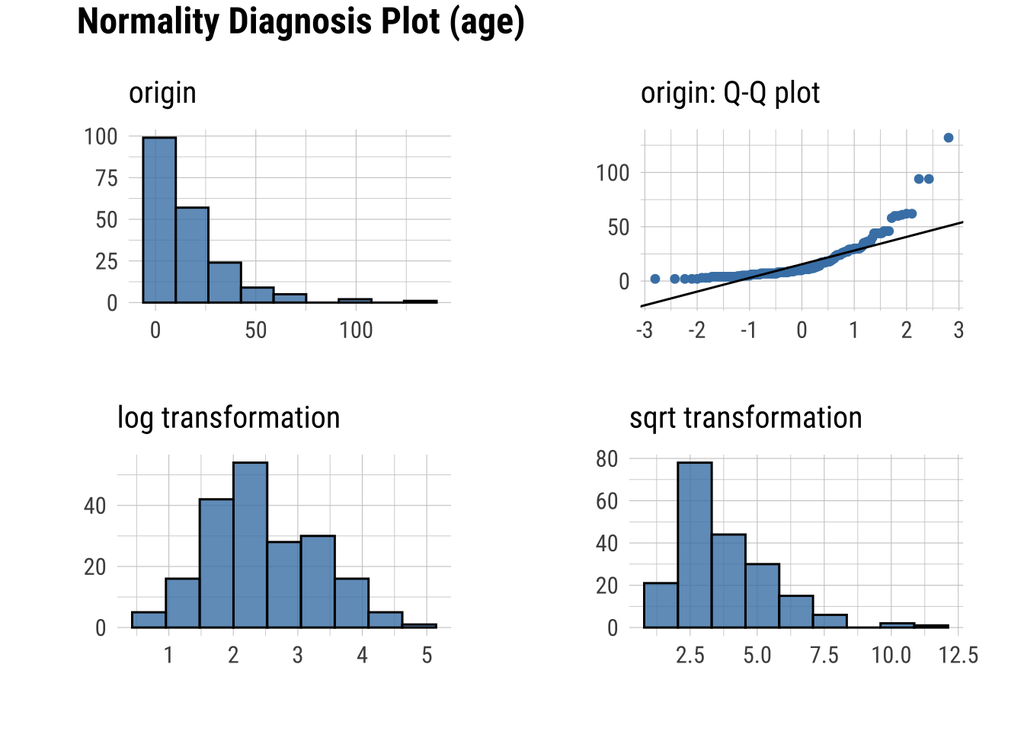

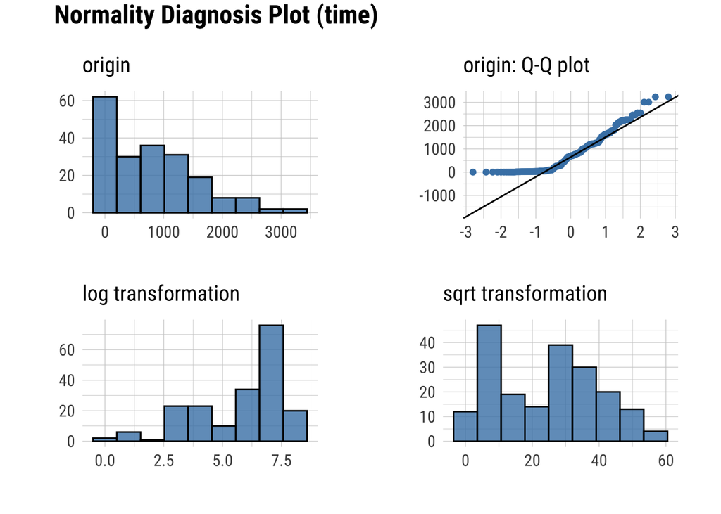

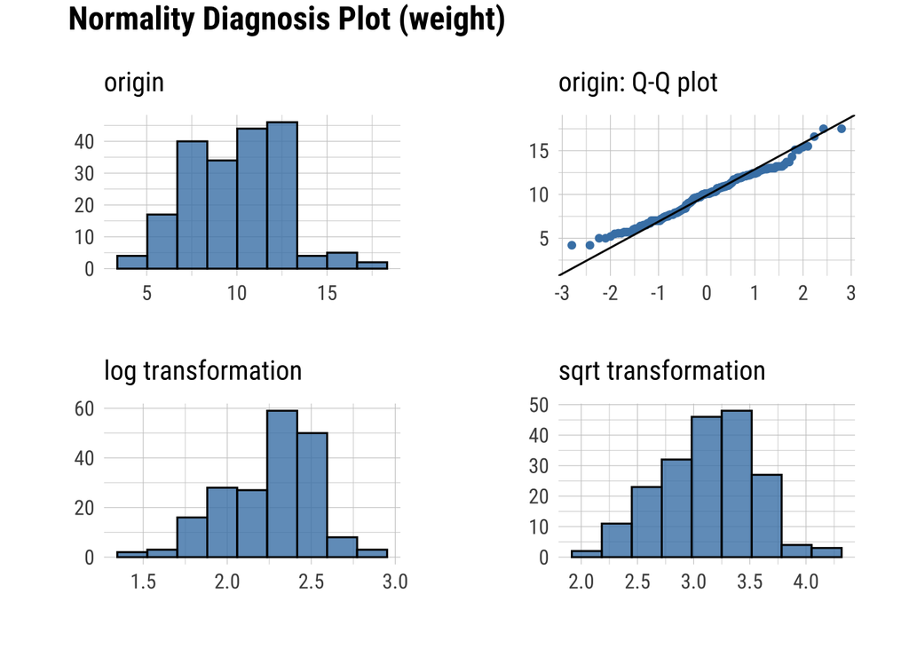

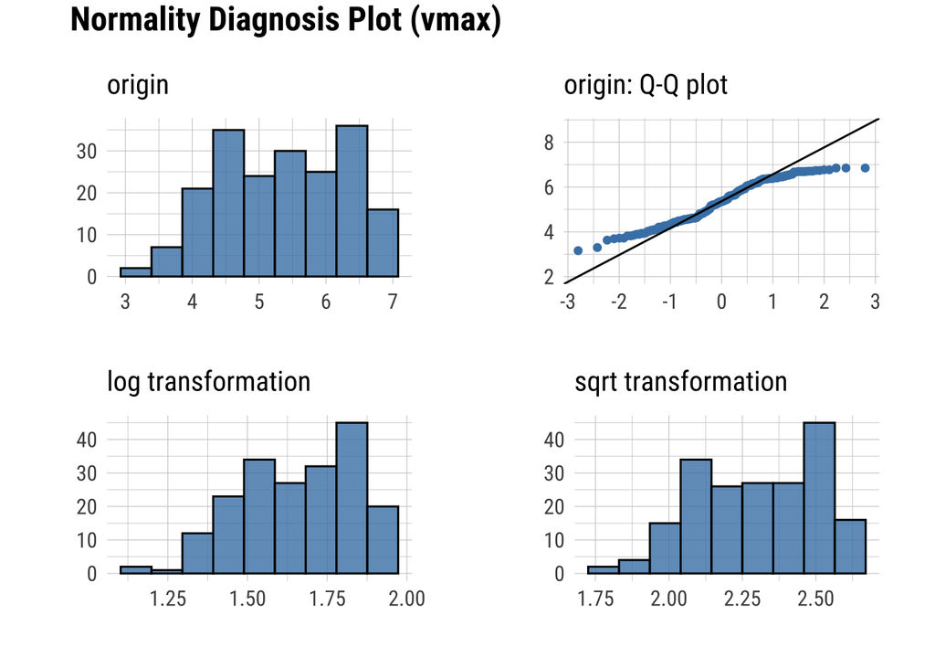

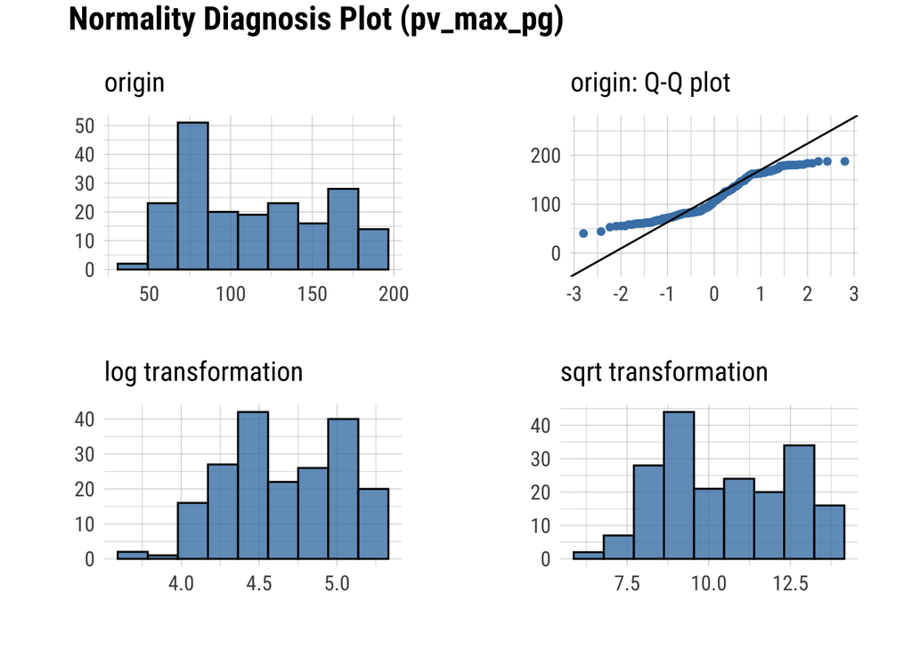

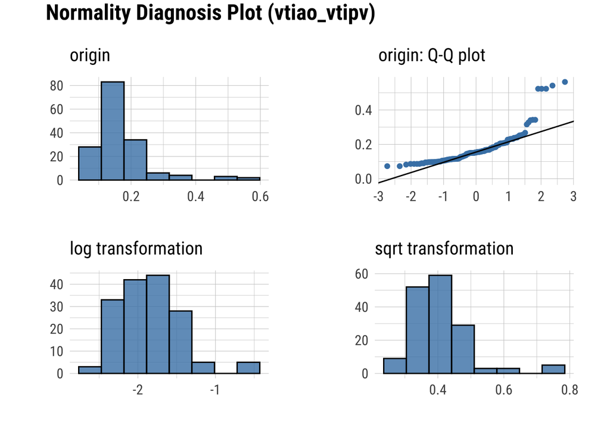

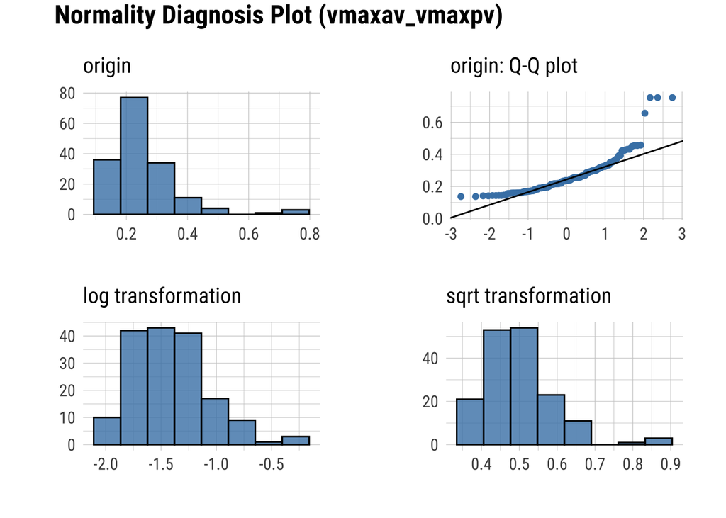

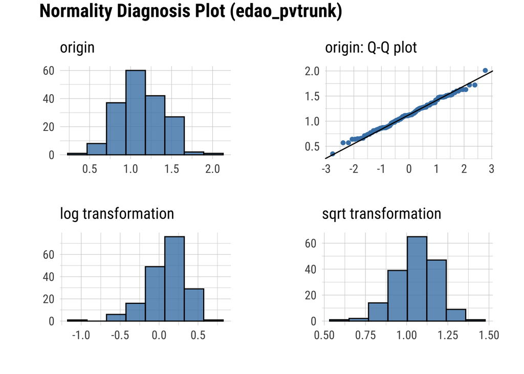

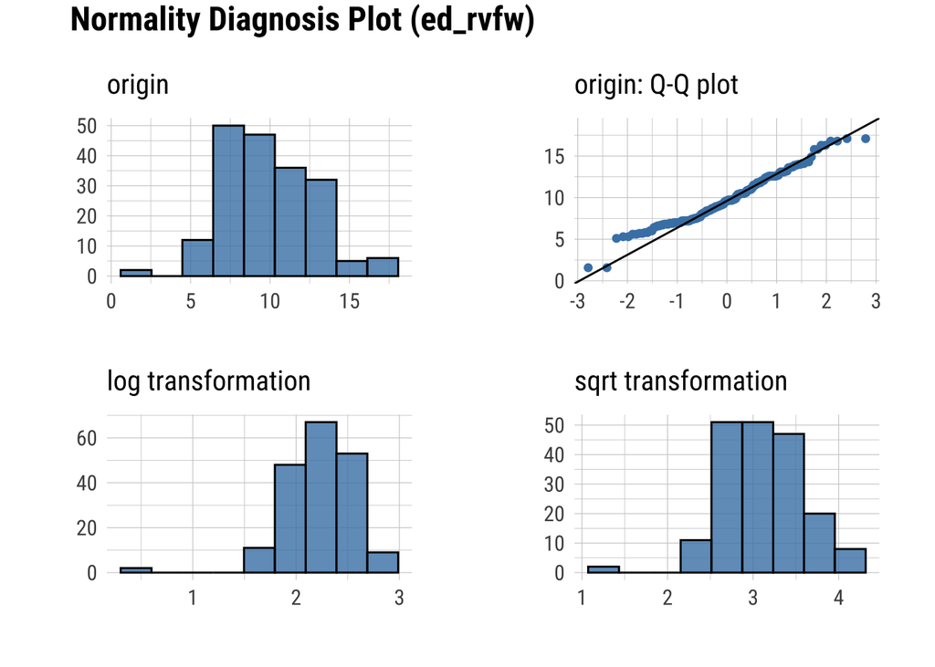

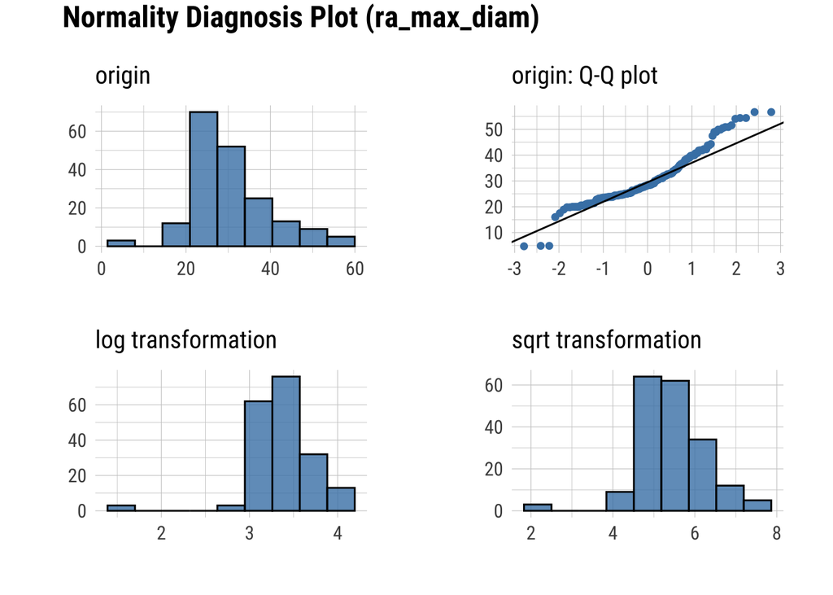

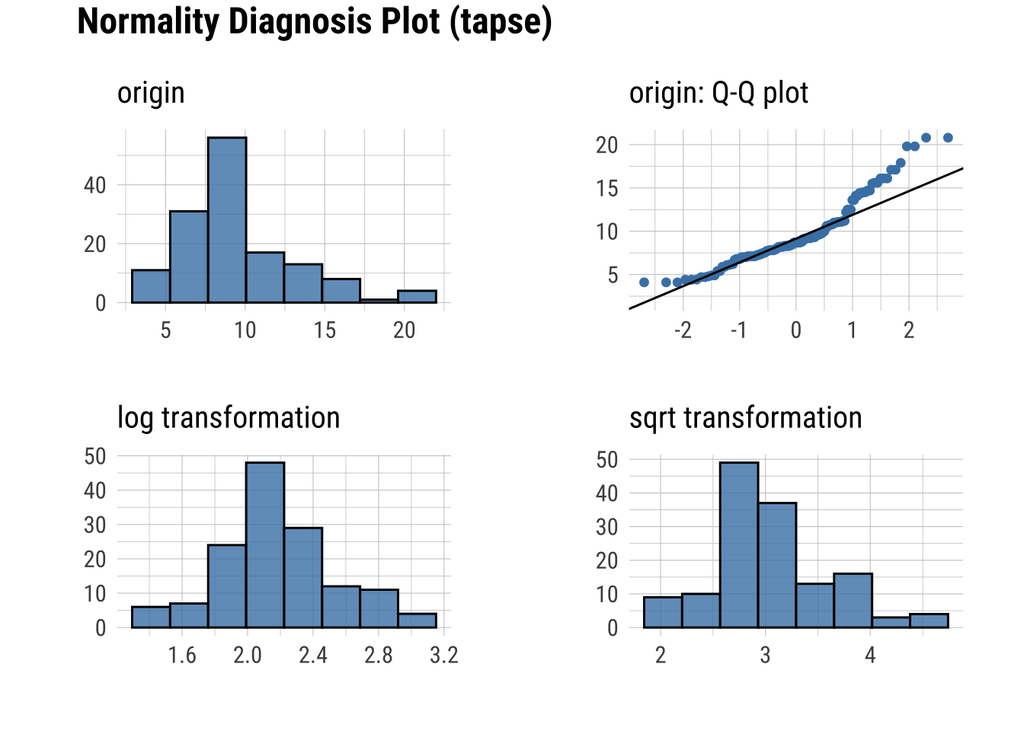

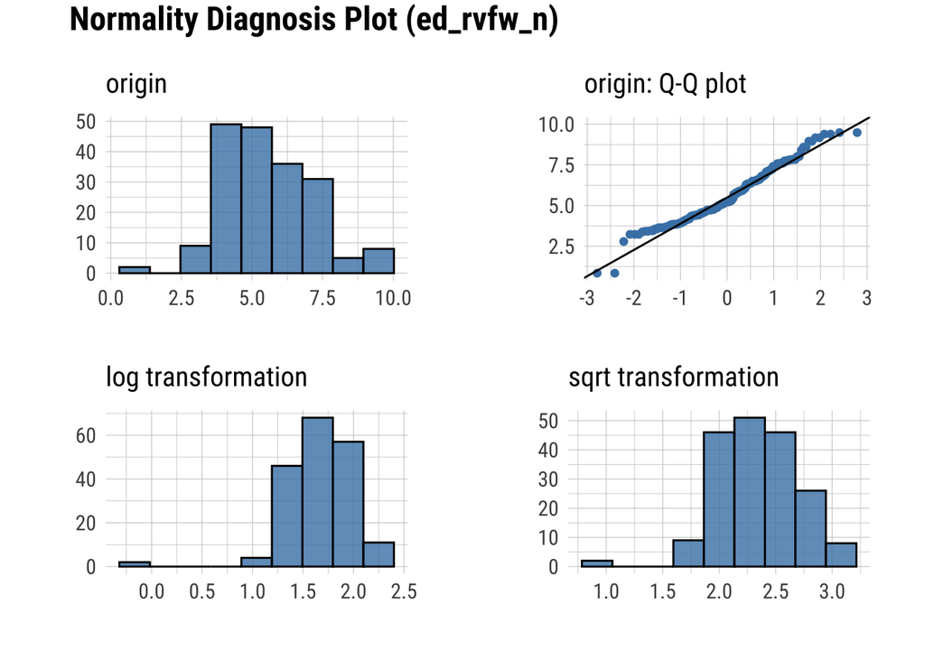

[2 more figures not shown]

```r
plot_normality(numeric_df)
```

# III. Bayesian multi-level survival analysis for EFFECT OF SURGERY (surgery y/n) with random intercept for centre

## Set prior for beta variables

**Set a neutral, weakly-regularising prior…**

```r
prior_beta_sx <- student_t(df = 3, location = 0, scale = 2, autoscale = c(FALSE, TRUE, FALSE, FALSE, FALSE, TRUE))
```

NB needed to set a tighter scale variable for prior_intercept and also prior_beta_sx in order to improve regularisation and resolve divergent transitions.

Based on the DAG, use the following adjustment variables: age, clin signs, concurrent congen, pressure grad, referral centre, stenosis type.

## Fit model with for surgery (plus correction set)

NB use status … rstanarm requires the dead animals to be classified as 1, whilst censored are 0.

```r
mod_sx <- stan_surv(formula = Surv(tstart, tstop, status) ~ surgery
                    + s_age
                    + concurrent_congenital
                    + type
                    + clinical_signs
                    + s_pv_max_pg
                    + (1| centre),
  data = df,
  basehaz = "ms",
  prior_intercept = normal(location = 0, scale = 10, autoscale = FALSE),
  prior = prior_beta_sx,
  prior_covariance =  decov(regularization = 2, concentration = 1, shape = 1, scale = 1),
  iter    = 12000,
  warmup = 4000,
  chains = 4,
  cores = 4,
  adapt_delta = 0.9999,  # Often helpful for complex models
  seed = 666)
```

[output not shown]

[output not shown]

[output not shown]

[output not shown]

[output not shown]

[output not shown]

[output not shown]

[output not shown]

[output not shown]

[output not shown]

## Summarise priors from model

```r
prior_summary(mod_sx)
```

```
## Priors for model 'mod_sx'
## ------
## Intercept
##  ~ normal(location = 0, scale = 10)
##
## Coefficients
##  ~ student_t(df = [3,3,3,...], location = [0,0,0,...], scale = [2,2,2,...])
##
## Auxiliary (M-spline-coefficients)
##  ~ dirichlet(concentration = [1,1,1,...])
##
## Covariance
##  ~ decov(reg. = 2, conc. = 1, shape = 1, scale = 1)
## ------
## See help('prior_summary.stanreg') for more details
```

## Model summary

```r
summary(mod_sx)
```

```
##
## Model Info:
##
##  function:        stan_surv
##  baseline hazard: M-splines on hazard scale
##  formula:         Surv(tstart, tstop, status) ~ surgery + s_age + concurrent_congenital +
##     type + clinical_signs + s_pv_max_pg + (1 | centre)
##  algorithm:       sampling
##  sample:          32000 (posterior sample size)
##  priors:          see help('prior_summary')
##  observations:    195
##  events:          40 (20.5%)
##  right censored:  155 (79.5%)
##  delayed entry:   yes
##
## Estimates:
##                                         mean   sd   10%   50%   90%
## (Intercept)                           -0.9    0.7 -1.7  -0.9  -0.1
## surgery1                              -0.1    0.4 -0.6  -0.1   0.4
## s_age                                 -0.1    0.2 -0.3  -0.1   0.2
## concurrent_congenital1                 0.8    0.3  0.4   0.8   1.2
## typeb                                 -0.1    0.5 -0.8  -0.1   0.5
## typeintermediate                       0.2    0.4 -0.4   0.2   0.7
## clinical_signs                         1.4    0.4  0.9   1.4   1.9
## s_pv_max_pg                            0.0    0.2 -0.3   0.0   0.2
## m-splines-coef1                        0.1    0.0  0.0   0.1   0.1
## m-splines-coef2                        0.1    0.1  0.0   0.1   0.2
## m-splines-coef3                        0.4    0.2  0.2   0.4   0.6
## m-splines-coef4                        0.2    0.2  0.0   0.2   0.5
## m-splines-coef5                        0.1    0.1  0.0   0.1   0.3
## m-splines-coef6                        0.1    0.1  0.0   0.1   0.3
## b[(Intercept) centre:p]               -0.3    0.5 -0.9  -0.2   0.2
## b[(Intercept) centre:sath]             0.3    0.5 -0.1   0.2   0.9
## b[(Intercept) centre:willows]          0.0    0.5 -0.4   0.0   0.5
## Sigma[centre:(Intercept),(Intercept)]  0.5    1.2  0.0   0.2   1.4
##
## MCMC diagnostics
##                                       mcse Rhat n_eff
## (Intercept)                           0.0  1.0  13522
## surgery1                              0.0  1.0  26107
## s_age                                 0.0  1.0  21258
## concurrent_congenital1                0.0  1.0  32414
## typeb                                 0.0  1.0  28985
## typeintermediate                      0.0  1.0  24425
## clinical_signs                        0.0  1.0  23243
## s_pv_max_pg                           0.0  1.0  30560
## m-splines-coef1                       0.0  1.0  26502
## m-splines-coef2                       0.0  1.0  29906
## m-splines-coef3                       0.0  1.0  22362
## m-splines-coef4                       0.0  1.0  20758
## m-splines-coef5                       0.0  1.0  40353
## m-splines-coef6                       0.0  1.0  36277
## b[(Intercept) centre:p]               0.0  1.0  12405
## b[(Intercept) centre:sath]            0.0  1.0   9723
## b[(Intercept) centre:willows]         0.0  1.0  10848
## Sigma[centre:(Intercept),(Intercept)] 0.0  1.0  13586
## log-posterior                         0.0  1.0  10309
##
## For each parameter, mcse is Monte Carlo standard error, n_eff is a crude measure of effective sample size, and Rhat is the potential scale reduction factor on split chains (at convergence Rhat=1).
```

## Model short summary

```r
print(mod_sx, digits = 3)
```

```
## stan_surv
##  baseline hazard: M-splines on hazard scale
##  formula:         Surv(tstart, tstop, status) ~ surgery + s_age + concurrent_congenital +
##     type + clinical_signs + s_pv_max_pg + (1 | centre)
##  observations:    195
##  events:          40 (20.5%)
##  right censored:  155 (79.5%)
##  delayed entry:   yes
## ------
##                        Median MAD_SD exp(Median)
## (Intercept)            -0.862  0.594     NA
## surgery1               -0.101  0.421  0.904
## s_age                  -0.050  0.175  0.951
## concurrent_congenital1  0.816  0.331  2.260
## typeb                  -0.119  0.534  0.887
## typeintermediate        0.166  0.408  1.181
## clinical_signs          1.415  0.407  4.116
## s_pv_max_pg            -0.034  0.176  0.966
## m-splines-coef1         0.057  0.032     NA
## m-splines-coef2         0.084  0.051     NA
## m-splines-coef3         0.357  0.165     NA
## m-splines-coef4         0.223  0.176     NA
## m-splines-coef5         0.093  0.091     NA
## m-splines-coef6         0.091  0.090     NA
##
## Error terms:
##  Groups Name        Std.Dev.
##  centre (Intercept) 0.7336
## Num. levels: centre 3
##
## ------
## * For help interpreting the printed output see ?print.stanreg
## * For info on the priors used see ?prior_summary.stanreg
```

## Plot Baseline hazard of model

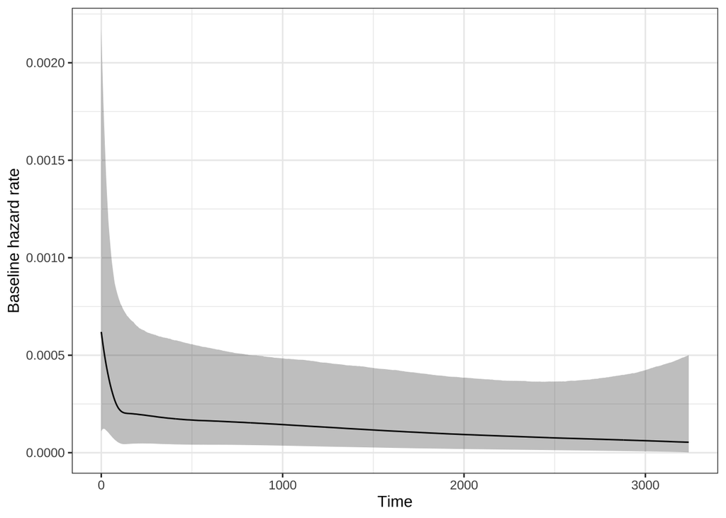

```r
plot(mod_sx)
```

## Plots of model convergences

## Get results

```r
posterior_mod_sx <- as.array(mod_sx)
```

### a. Check trace plots for model

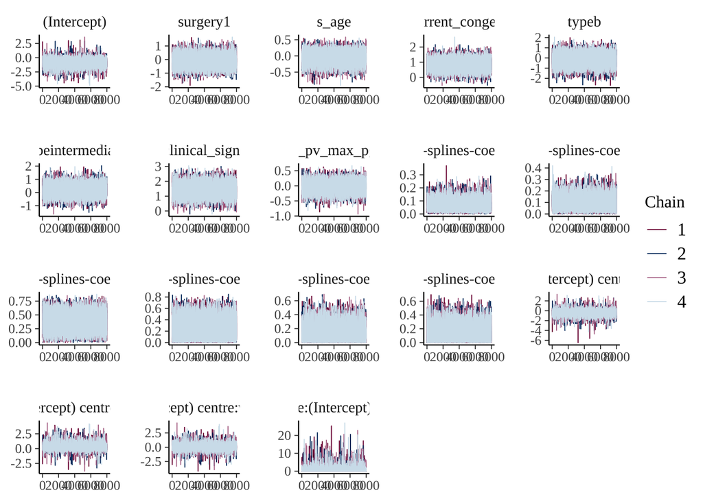

```r
color_scheme_set("mix-blue-pink")
mcmc_trace(posterior_mod_sx)
```

### b. Trace rank plot

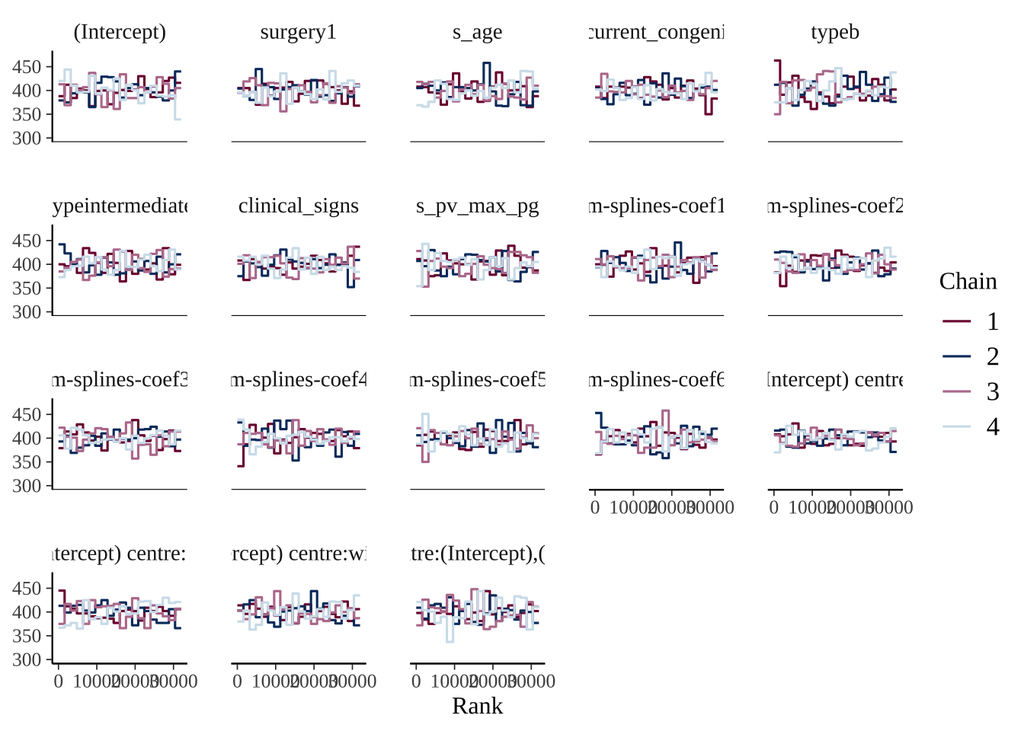

```r
color_scheme_set("mix-blue-pink")
mcmc_rank_overlay(posterior_mod_sx) +
  ylim(c(300, 475))
```

### c. get dens overlay plot for chains

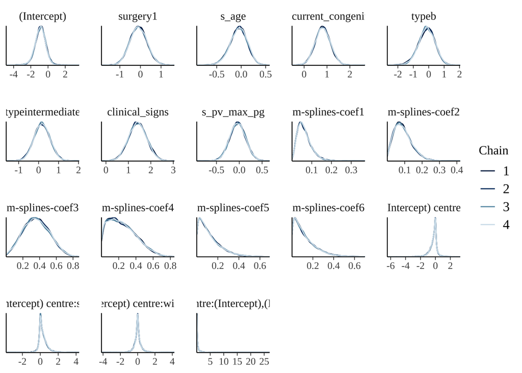

```r
color_scheme_set("blue")
mcmc_dens_overlay(posterior_mod_sx)
```

## Summaries of coefficients

### a. HPDI for the different beta parameters

```r
draws <- as.matrix(mod_sx)
median(draws[,2]) # draws for surgery
```

```
## [1] -0.1013986
```

```r
HPDI(draws[,2], 0.97) # draws for surgery
```

```
##      |0.97      0.97|
## -1.0116999  0.8141885
```

```r
HPDI(draws[,2], 0.89) # draws for surgery
```

```
##      |0.89      0.89|
## -0.7656480  0.5704044
```

### b. Hypothesis tests on beta parameters

#### surgery

probability that effect is negative

```r
mean(draws[,2] < 0) # draws for surgery
```

```
## [1] 0.5928438
```

### c. Plot posterior distribution for beta coefficient of surgery

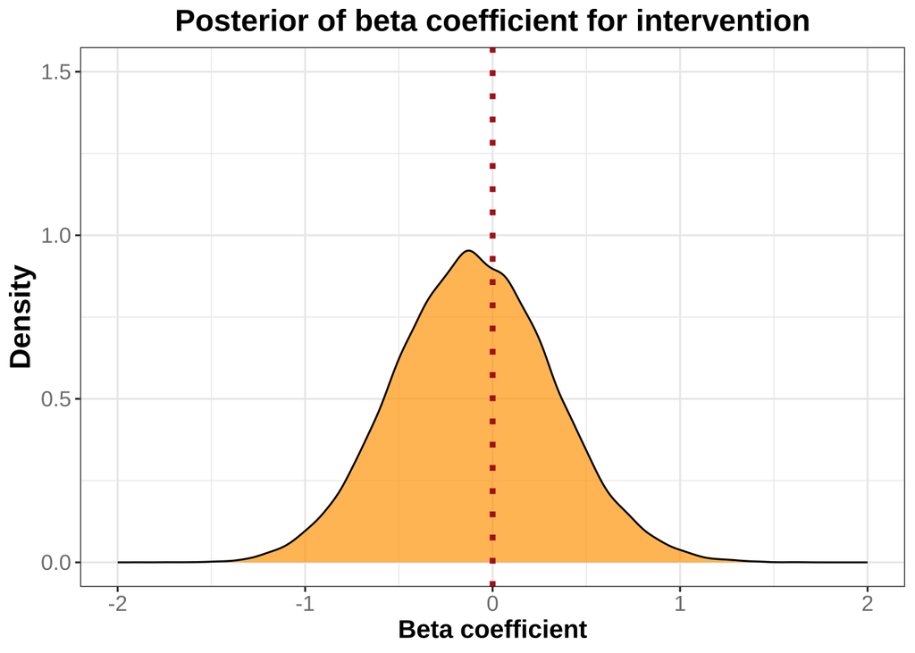

```r
s_sx <- draws[,2] # 2nd column is draws for surgery

ggplot(data.frame(s_sx), aes(x = s_sx)) +
  geom_density(fill = "orange", alpha = 0.7) +
  labs(title = "Posterior of beta coefficient for intervention",
       x = "Beta coefficient",
       y = "Density") +
  theme_bw() +
           theme(axis.title.y = element_text(size=16, face="bold"),
               axis.title.x = element_text(size=14, face="bold"),
               title = element_text(size=14, face="bold"),
               plot.title = element_text(hjust = 0.5),
               axis.text.x = element_text(color = "grey50", size = 12),
               axis.text.y = element_text(color = "grey50",size = 12)) +
  geom_vline(xintercept = 0, linetype="dotted",
                color = "firebrick", linewidth = 1.5)  +
                ylim(0, 1.5) +
                xlim(-2.0, 2.0)
```

## Get HDI for coefficients

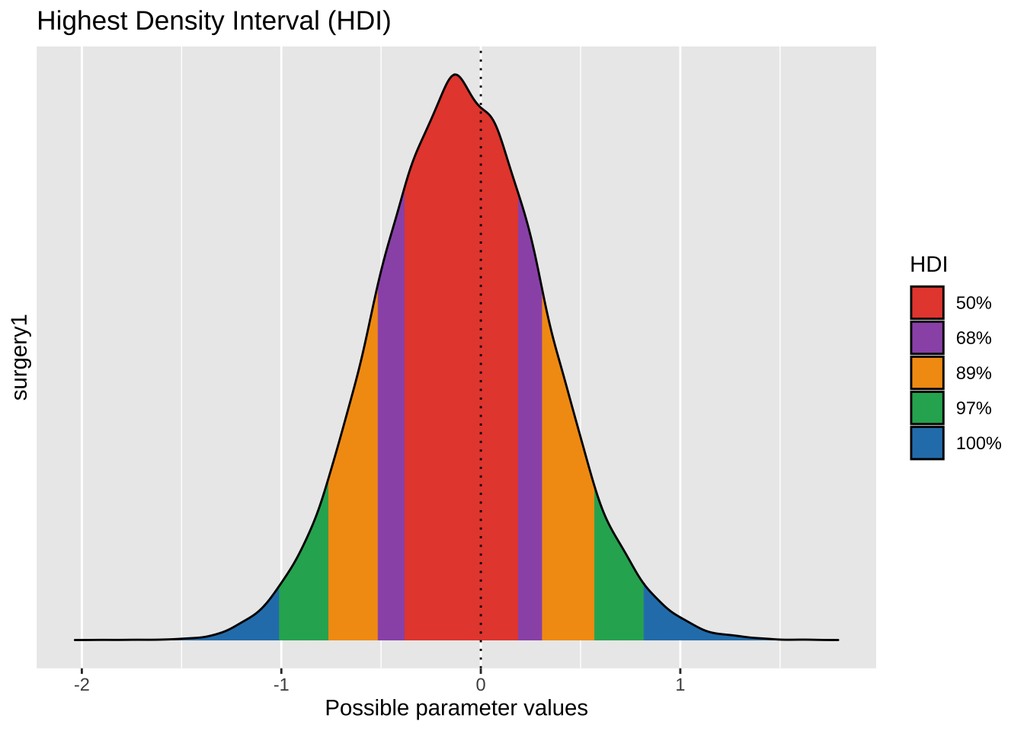

```r
hdi <- bayestestR::hdi(mod_sx, ci = c(0.50, 0.68, 0.89, 0.97), parameters = "surgery")
plot(hdi)
```

## Get density plots for posterior distributons of beta parameters

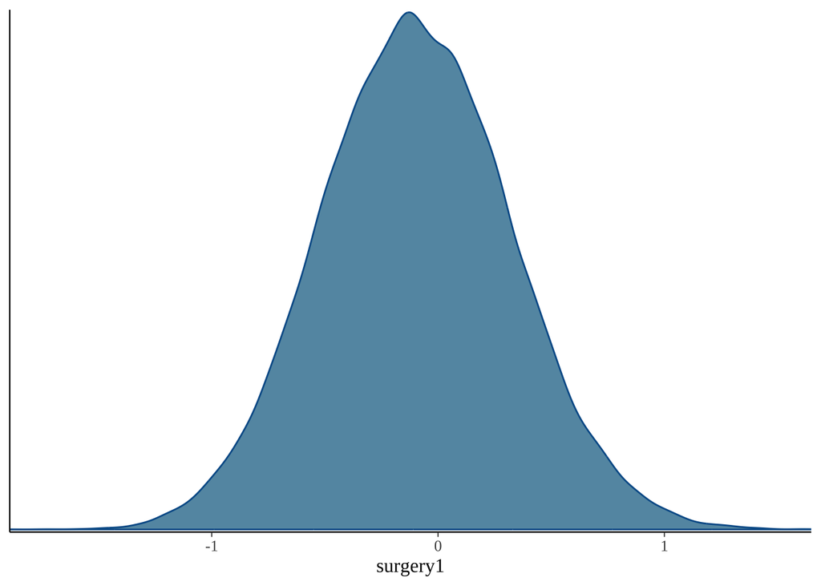

```r
mcmc_dens(posterior_mod_sx,
  pars = c("surgery1"))
```

## Get area plot for posterior distributons of beta parameters

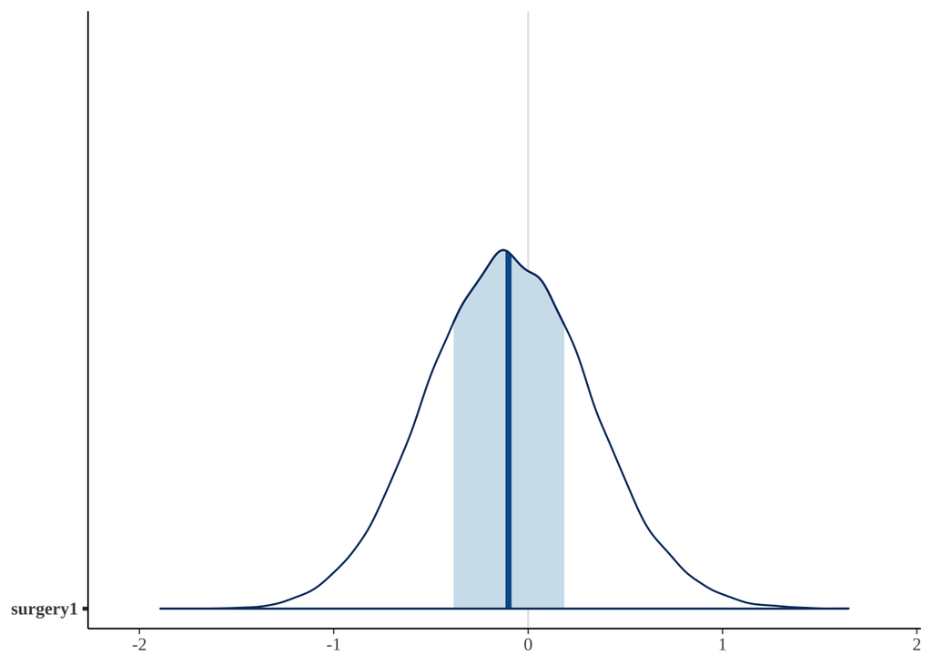

```r
mcmc_areas(posterior_mod_sx,
  pars = "surgery1")
```

## Calculate hazard ratios for surgery

### a. get posterior draws

```r
surgery_hr <- exp(draws[,2]) # 2nd column is draws for surgery)
```

### b. Summarise hazard ratios for surgery

```r
median(surgery_hr)
```

```
## [1] 0.9035728
```

```r
hpdi_surgery <- HPDI(surgery_hr, prob = c(0.89, 0.97))
hpdi_surgery
```

```
##     |0.97     |0.89     0.89|     0.97|
## 0.2953913 0.3743055 1.5779919 2.0668506
```

### c. Plot posterior distribution for hazard ratio of surgery

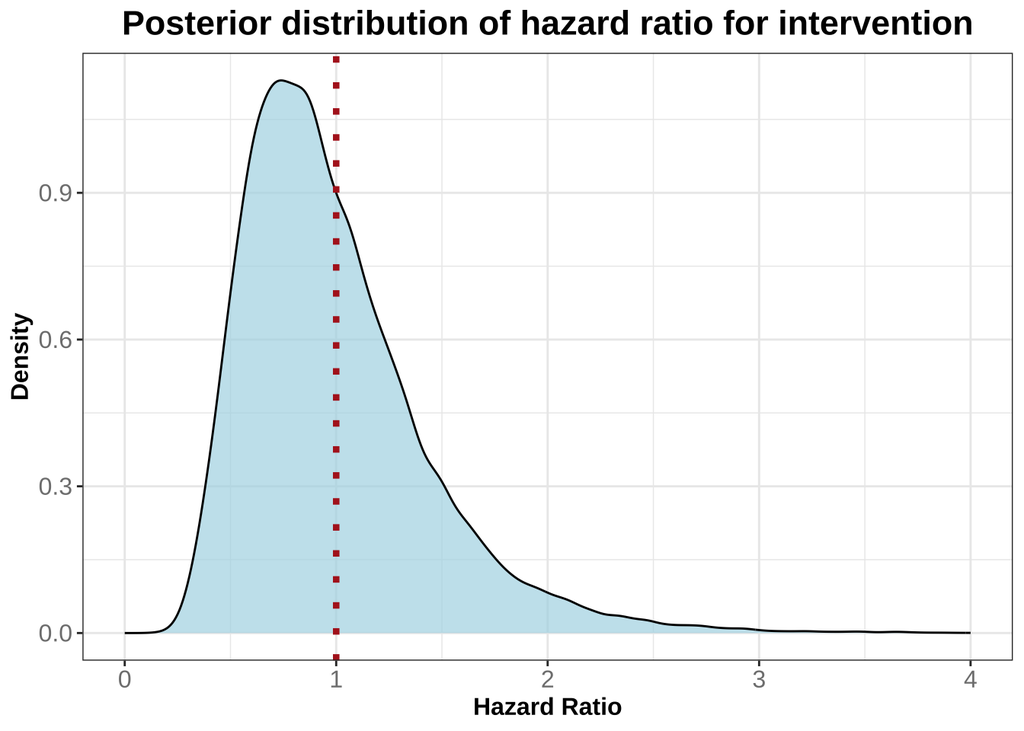

```r
ggplot(data.frame(surgery_hr), aes(x = surgery_hr)) +
  geom_density(fill = "lightblue", alpha = 0.7) +
  labs(title = "Posterior distribution of hazard ratio for intervention",
       x = "Hazard Ratio",
       y = "Density") +
  theme_bw() +
           theme(axis.title.y = element_text(size=12, face="bold"),
               axis.title.x = element_text(size=12, face="bold"),
               title = element_text(size=14, face="bold"),
               plot.title = element_text(hjust = 0.5),
               axis.text.x = element_text(color = "grey50", size = 12),
               axis.text.y = element_text(color = "grey50",size = 12)) +
  geom_vline(xintercept = 1, linetype="dotted",
                color = "firebrick", linewidth = 1.5) +
  xlim(0, 4)
```

### 2. Check performance of prior probability

```r
mod_sx_prior_only <- update(mod_sx, prior_PD = TRUE)
```

[output not shown]

[output not shown]

[output not shown]

[output not shown]

[output not shown]

[output not shown]

[output not shown]

[output not shown]

[output not shown]

[output not shown]

### 3. Check prosterior vs prior for beta variable

#### a. extract draws for posterior and prior

```r
# extract draws
post_draws  <- as.matrix(mod_sx)
prior_draws <- as.matrix(mod_sx_prior_only)
```

#### b. plot marginal distributions for posterior and prior

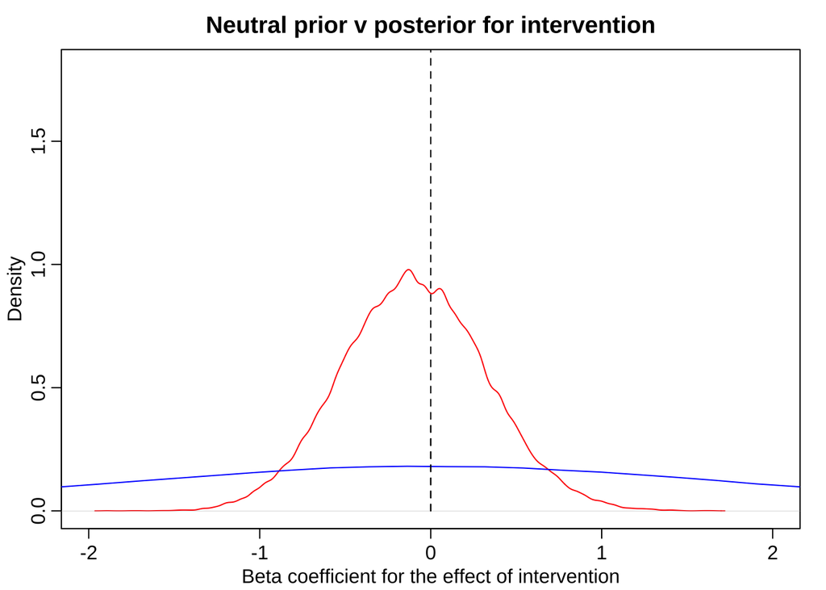

```r
# Compare marginal distributions
dens(post_draws[, "surgery1"], show.zero = TRUE, col = "red", main = "Neutral prior v posterior for intervention", xlab = "Beta coefficient for the effect of intervention", xlim = c(-2, 2), ylim = c(0, 1.8))
dens(prior_draws[, "surgery1"], add=TRUE, col = "blue", show.zero = TRUE)
```

#### c. compute prior tail probability of posterior mean

If this probability is very small (e.g. < 0.05), the posterior lies in a region the prior considered implausible.

```r
beta_hat <- mean(post_draws[, "surgery1"])

mean(abs(prior_draws[, "surgery1"] - beta_hat) <
       abs(prior_draws[, "surgery1"] - mean(prior_draws[, "surgery1"])))
```

```
## [1] 0.4917813
```

### 4. Sensitivity analyses to assess robustness of results to choice of prior

#### a. create priors of different strength for surgery1 variable

To determine whether the substantive conclusions depend upon the exact prior choice.

```r
priors_bin <- list(
  weak = student_t(df = 3, location = 0, scale = 2.5, autoscale = c(FALSE, TRUE, FALSE, FALSE, FALSE, TRUE)),
  moderate = student_t(df = 3, location = 0, scale = 1.25, autoscale = c(FALSE, TRUE, FALSE, FALSE, FALSE, TRUE)),
  strong = student_t(df = 3, location = 0, scale = 0.625, autoscale = c(FALSE, TRUE, FALSE, FALSE, FALSE, TRUE))
)
```

#### b. refit model with different priors and compare results

```r
fits <- lapply(priors_bin, function(p) {
  stan_surv(formula = Surv(tstart, tstop, status) ~ surgery
                    + s_age
                    + concurrent_congenital
                    + type
                    + clinical_signs
                    + s_pv_max_pg
                    + (1| centre),
            basehaz = "ms",
            data = df,
            prior_intercept = normal(location = 0, scale = 10, autoscale = FALSE),
            prior = p,
            prior_covariance =  decov(regularization = 2, concentration = 1, shape = 1, scale = 1),
            iter    = 2000,
            chains = 4,
            cores = 4,
            adapt_delta = 0.9999,  # Often helpful for complex models
            seed = 666
            )
})
```

[output not shown]

[output not shown]

[output not shown]

[output not shown]

[output not shown]

[output not shown]

[output not shown]

[output not shown]

[output not shown]

[output not shown]

[output not shown]

[output not shown]

[output not shown]

[output not shown]

[output not shown]

[output not shown]

[output not shown]

[output not shown]

[output not shown]

[output not shown]

[output not shown]

[output not shown]

[output not shown]

[output not shown]

[output not shown]

[output not shown]

[output not shown]

[output not shown]

[output not shown]

#### c. compare posterior intervals for hazard ratios for intervention across different priors

```r
# calculate median hazard ratio across different priors
HR_med_sens <- sapply(fits, function(f) {
  posterior::as_draws_df(f) |>
    as.data.frame() |>
    summarise(
      median = exp(quantile(surgery1, probs = 0.5))
    )
})
HR_med <- c(HR_med_sens[[1]], HR_med_sens[[2]], HR_med_sens[[3]])


# calculate 89% credible interval for hazard ratio across different priors
HR_sens <- sapply(fits, function(f) {
  exp(posterior_interval(f, pars = "surgery1", prob = 0.89))
})

# combine median and credible intervals into a summary table
HR_sens_summary <- rbind(HR_med, HR_sens)
row.names(HR_sens_summary) <- c("Median", "Lower", "Upper")

# transpose the table for better readability
HR_sens_summary
```

```
##             weak  moderate    strong
## Median 0.9168457 0.9195075 0.9336238
## Lower  0.4697230 0.4865985 0.5340586
## Upper  1.8231876 1.7721314 1.6421245
```

## Make model predictions and plot for surgery

```r
nd <- data.frame(centre = rep("p", 2),
                 surgery = c(0, 1),
                 s_pv_max_pg = rep(0, 2),
                 concurrent_congenital = rep(0, 2),
                 type = rep("a", 2),
                 s_age = rep(0, 2),
                 clinical_signs = rep(0, 2)
                 )
head(nd)
```

```
##   centre surgery s_pv_max_pg concurrent_congenital type s_age clinical_signs
## 1      p       0           0                     0    a     0              0
## 2      p       1           0                     0    a     0              0
```

### 2. Make posterior predictions from new data

```r
ps <- posterior_survfit(mod_sx,
  newdata = nd,
  times = 0,
  extrapolate = TRUE) |>
  suppressWarnings()
head(ps)
```

```
## stan_surv predictions
##  num. individuals: 2
##  prediction type:  event free probability
##  standardised?:    no
##  conditional?:     no
##
##   id cond_time     time median  ci_lb  ci_ub
## 1  1        NA   0.0000 1.0000 1.0000 1.0000
## 2  1        NA  32.7172 0.9867 0.9590 0.9965
## 3  1        NA  65.4343 0.9776 0.9329 0.9937
## 4  1        NA  98.1515 0.9700 0.9176 0.9921
## 5  1        NA 130.8687 0.9648 0.8996 0.9908
## 6  1        NA 163.5859 0.9595 0.8823 0.9894
```

### 3. Plot

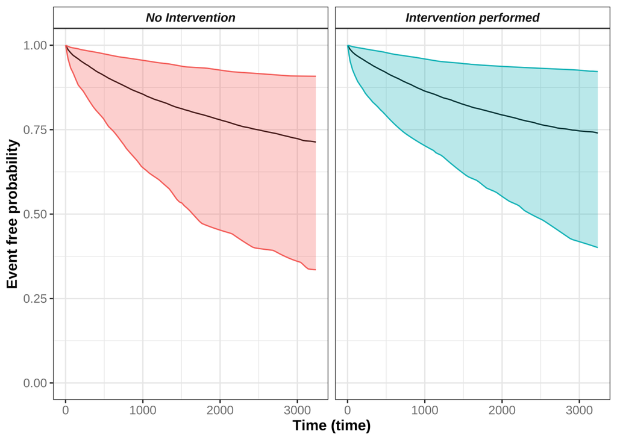

```r
panel_labels <- c('1' = "No Intervention", '2' = "Intervention performed")
pps <- plot(ps) +
  aes(colour = factor(id), fill = factor(id)) +
  theme(legend.position = "none") +
  facet_wrap(~ id, labeller = labeller(id = panel_labels)) +
           theme(axis.title.y = element_text(size=12, face="bold"),
               axis.title.x = element_text(size=12, face="bold"),
               title = element_text(size=12, face="bold"),
               plot.title = element_text(hjust = 0.5),
               axis.text.x = element_text(color = "grey50", size = 10),
               axis.text.y = element_text(color = "grey50",size = 10)) +
            theme(strip.text.x = element_text(size = 10, face = "bold.italic"),
                   strip.background = element_rect(fill="white")
        )

print(pps)
```

## Check PH assumption visually

### make predictions of both the hazard and log hazard

```r
ph <- suppressWarnings(posterior_survfit(mod_sx, newdata = nd, type = "haz"))
pl <- suppressWarnings(posterior_survfit(mod_sx, newdata = nd, type = "loghaz"))
```

#### create plots

```r
pph <- plot(ph) +
  facet_wrap(~ id, labeller = labeller(id = panel_labels))
ppl <- plot(pl) +
  facet_wrap(~ id, labeller = labeller(id = panel_labels))
```

#### combine plots in grid and plot

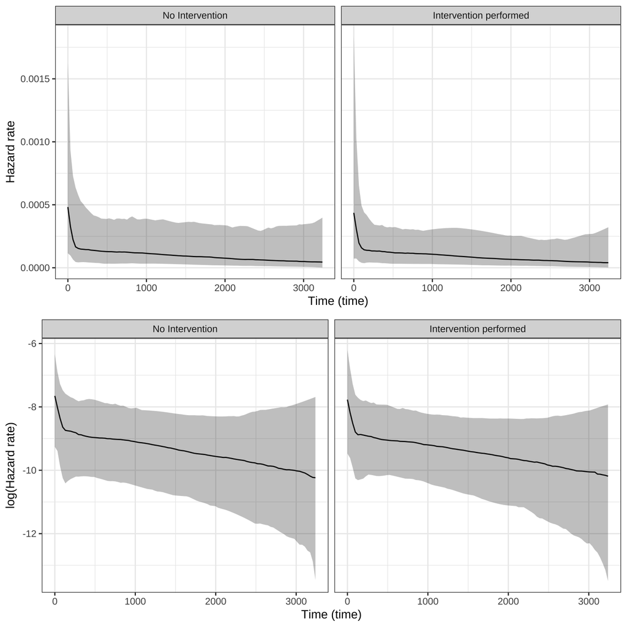

```r
plot_grid(pph, ppl, ncol = 1)
```

# XIIa. Bayesian multi-level survival analysis for effect of atenolol_pre with random intercept for centre and control set

## Set prior for beta variables

**Set a neutral, weakly-regularising prior…**

```r
prior_beta_aten_pre <- student_t(df = 3, location = 0, scale = 1.75, autoscale = c(FALSE, TRUE))
```

Based on the DAG, use the following adjustment variables: RV syst dys, referral centre.

## Fit model

NB use status … rstanarm requires the dead animals to be classified as 1, whilst censored are 0.

```r
mod_aten_pre <- stan_surv(formula = Surv(tstart, tstop, status) ~ atenolol_pre
                      + s_tapse
                      + (1| centre),
  data = df,
  basehaz = "ms",
  prior_intercept = normal(location = 0, scale = 20, autoscale = FALSE),
  prior = prior_beta_aten_pre,
  prior_covariance =  decov(regularization = 2, concentration = 1, shape = 1, scale = 1),
  iter    = 12000,
  warmup = 4000,
  chains = 4,
  cores = 4,
  adapt_delta = 0.99999,  # Often helpful for complex models
  control = list(max_treedepth = 20),
  init = 0.1,
  seed = 666)
```

[output not shown]

[output not shown]

[output not shown]

[output not shown]

[output not shown]

[output not shown]

[output not shown]

[output not shown]

[output not shown]

[output not shown]

## Summarise priors from model

```r
prior_summary(mod_aten_pre)
```

```
## Priors for model 'mod_aten_pre'
## ------
## Intercept
##  ~ normal(location = 0, scale = 20)
##
## Coefficients
##  ~ student_t(df = [3,3], location = [0,0], scale = [1.8,1.8])
##
## Auxiliary (M-spline-coefficients)
##  ~ dirichlet(concentration = [1,1,1,...])
##
## Covariance
##  ~ decov(reg. = 2, conc. = 1, shape = 1, scale = 1)
## ------
## See help('prior_summary.stanreg') for more details
```

## Model summary

```r
summary(mod_aten_pre)
```

```
##
## Model Info:
##
##  function:        stan_surv
##  baseline hazard: M-splines on hazard scale
##  formula:         Surv(tstart, tstop, status) ~ atenolol_pre + s_tapse + (1 | centre)
##  algorithm:       sampling
##  sample:          32000 (posterior sample size)
##  priors:          see help('prior_summary')
##  observations:    141
##  events:          30 (21.3%)
##  right censored:  111 (78.7%)
##  delayed entry:   yes
##
## Estimates:
##                                         mean   sd   10%   50%   90%
## (Intercept)                            0.6    0.6 -0.1   0.6   1.3
## atenolol_pre                          -0.8    0.5 -1.3  -0.8  -0.2
## s_tapse                               -0.3    0.2 -0.6  -0.3   0.0
## m-splines-coef1                        0.1    0.0  0.0   0.1   0.2
## m-splines-coef2                        0.1    0.1  0.0   0.1   0.2
## m-splines-coef3                        0.4    0.1  0.3   0.4   0.6
## m-splines-coef4                        0.2    0.1  0.0   0.1   0.3
## m-splines-coef5                        0.1    0.1  0.0   0.1   0.2
## m-splines-coef6                        0.1    0.1  0.0   0.1   0.3
## b[(Intercept) centre:p]               -0.2    0.4 -0.7  -0.1   0.2
## b[(Intercept) centre:sath]             0.2    0.4 -0.2   0.1   0.7
## b[(Intercept) centre:willows]          0.0    0.4 -0.3   0.0   0.4
## Sigma[centre:(Intercept),(Intercept)]  0.4    1.0  0.0   0.1   1.0
##
## MCMC diagnostics
##                                       mcse Rhat n_eff
## (Intercept)                           0.0  1.0  16437
## atenolol_pre                          0.0  1.0  32668
## s_tapse                               0.0  1.0  32957
## m-splines-coef1                       0.0  1.0  43897
## m-splines-coef2                       0.0  1.0  26814
## m-splines-coef3                       0.0  1.0  30724
## m-splines-coef4                       0.0  1.0  29044
## m-splines-coef5                       0.0  1.0  40466
## m-splines-coef6                       0.0  1.0  37475
## b[(Intercept) centre:p]               0.0  1.0  13435
## b[(Intercept) centre:sath]            0.0  1.0  11139
## b[(Intercept) centre:willows]         0.0  1.0  11283
## Sigma[centre:(Intercept),(Intercept)] 0.0  1.0  13232
## log-posterior                         0.0  1.0   9796
##
## For each parameter, mcse is Monte Carlo standard error, n_eff is a crude measure of effective sample size, and Rhat is the potential scale reduction factor on split chains (at convergence Rhat=1).
```

## Model short summary

```r
print(mod_aten_pre, digits = 3)
```

```
## stan_surv
##  baseline hazard: M-splines on hazard scale
##  formula:         Surv(tstart, tstop, status) ~ atenolol_pre + s_tapse + (1 | centre)
##  observations:    141
##  events:          30 (21.3%)
##  right censored:  111 (78.7%)
##  delayed entry:   yes
## ------
##                 Median MAD_SD exp(Median)
## (Intercept)      0.594  0.524     NA
## atenolol_pre    -0.799  0.446  0.450
## s_tapse         -0.332  0.236  0.717
## m-splines-coef1  0.087  0.043     NA
## m-splines-coef2  0.068  0.055     NA
## m-splines-coef3  0.447  0.147     NA
## m-splines-coef4  0.127  0.120     NA
## m-splines-coef5  0.081  0.080     NA
## m-splines-coef6  0.094  0.092     NA
##
## Error terms:
##  Groups Name        Std.Dev.
##  centre (Intercept) 0.6297
## Num. levels: centre 3
##
## ------
## * For help interpreting the printed output see ?print.stanreg
## * For info on the priors used see ?prior_summary.stanreg
```

## Plot Baseline hazard of model

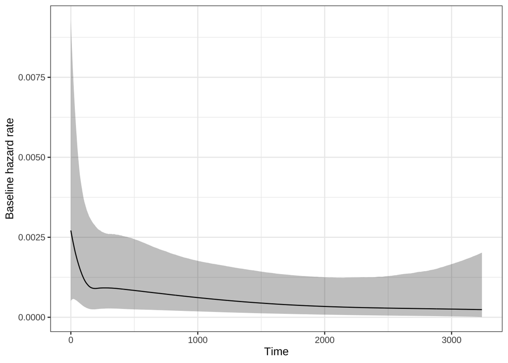

```r
plot(mod_aten_pre)
```

## Plots of model convergences

## Get results

```r
posterior_mod_aten_pre <- as.array(mod_aten_pre)
```

### a. Check trace plots for model

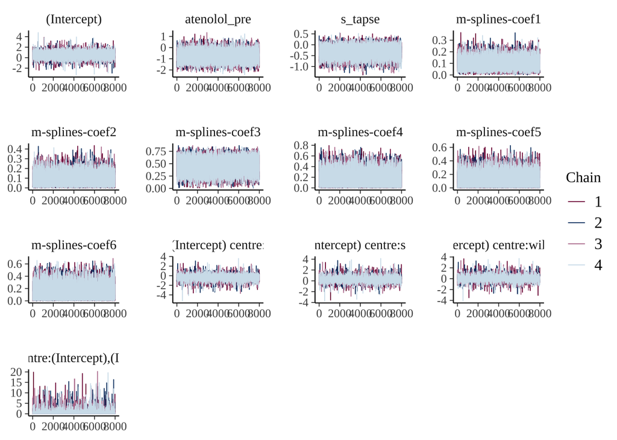

```r
color_scheme_set("mix-blue-pink")
mcmc_trace(posterior_mod_aten_pre)
```

### b. Trace rank plot

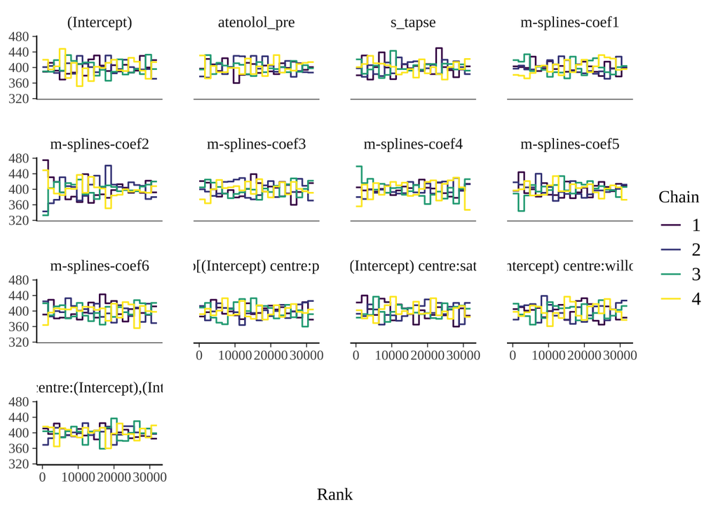

```r
color_scheme_set("viridis")
mcmc_rank_overlay(posterior_mod_aten_pre) +
  ylim(325,475)
```

### c. get dens overlay plot for chains

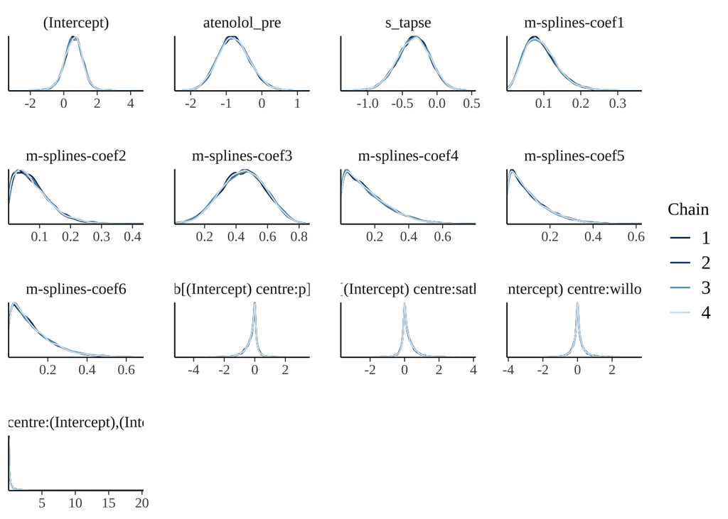

```r
color_scheme_set("blue")
mcmc_dens_overlay(posterior_mod_aten_pre)
```

## Summaries of coefficients

### a. HPDI for the different beta parameters

```r
draws <- as.matrix(mod_aten_pre)
median(draws[,2]) # draws for atenolol_pre
```

```
## [1] -0.7987848
```

```r
HPDI(draws[,2], 0.97) # draws for atenolol_pre
```

```
##      |0.97      0.97|
## -1.7837094  0.1774366
```

```r
HPDI(draws[,2], 0.89) # draws for atenolol_pre
```

```
##       |0.89       0.89|
## -1.51769532 -0.08778681
```

### b. Hypothesis tests on beta parameters

#### i. probability that effect is positive

```r
mean(draws[,2] > 0) # draws for atenolol_pre
```

```
## [1] 0.04578125
```

#### ii. probability that effect is negative

```r
mean(draws[,2] < 0) # draws for atenolol_pre
```

```
## [1] 0.9542188
```

### c. Plot posterior distribution for beta coefficient of s_aten_pre

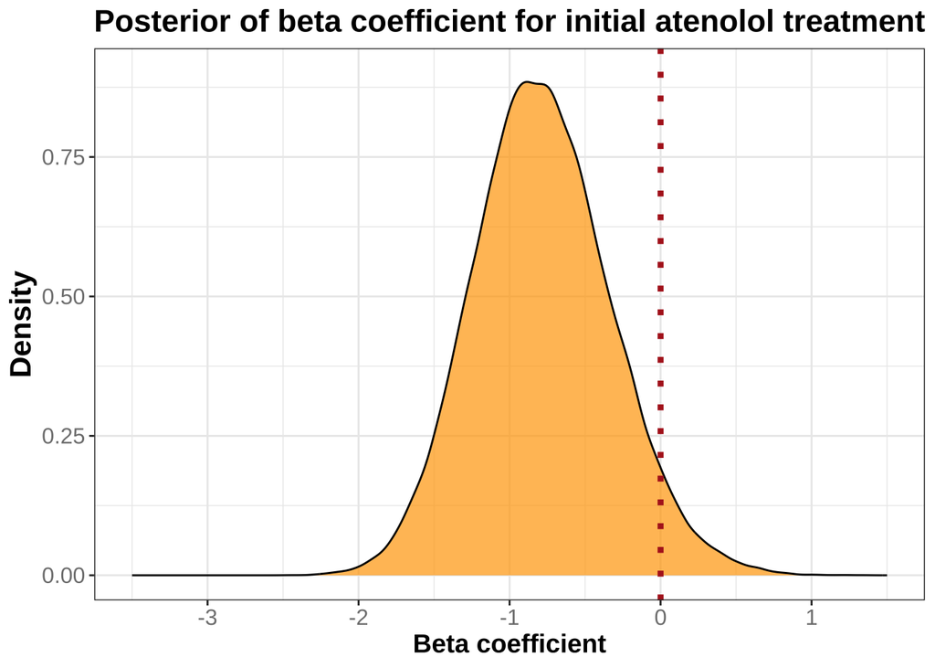

```r
s_aten_pre <- draws[,2] # 2nd column is draws for s_aten_pre

ggplot(data.frame(s_aten_pre), aes(x = s_aten_pre)) +
  geom_density(fill = "orange", alpha = 0.7) +
  labs(title = "Posterior of beta coefficient for initial atenolol treatment",
       x = "Beta coefficient",
       y = "Density") +
  theme_bw() +
           theme(axis.title.y = element_text(size=16, face="bold"),
               axis.title.x = element_text(size=14, face="bold"),
               title = element_text(size=14, face="bold"),
               plot.title = element_text(hjust = 0.5),
               axis.text.x = element_text(color = "grey50", size = 12),
               axis.text.y = element_text(color = "grey50",size = 12)) +
  geom_vline(xintercept = 0, linetype="dotted",
                color = "firebrick", linewidth = 1.5) +
              xlim(-3.5, 1.5) +
              ylim(0, 0.9)
```

## Get HDI for coefficients

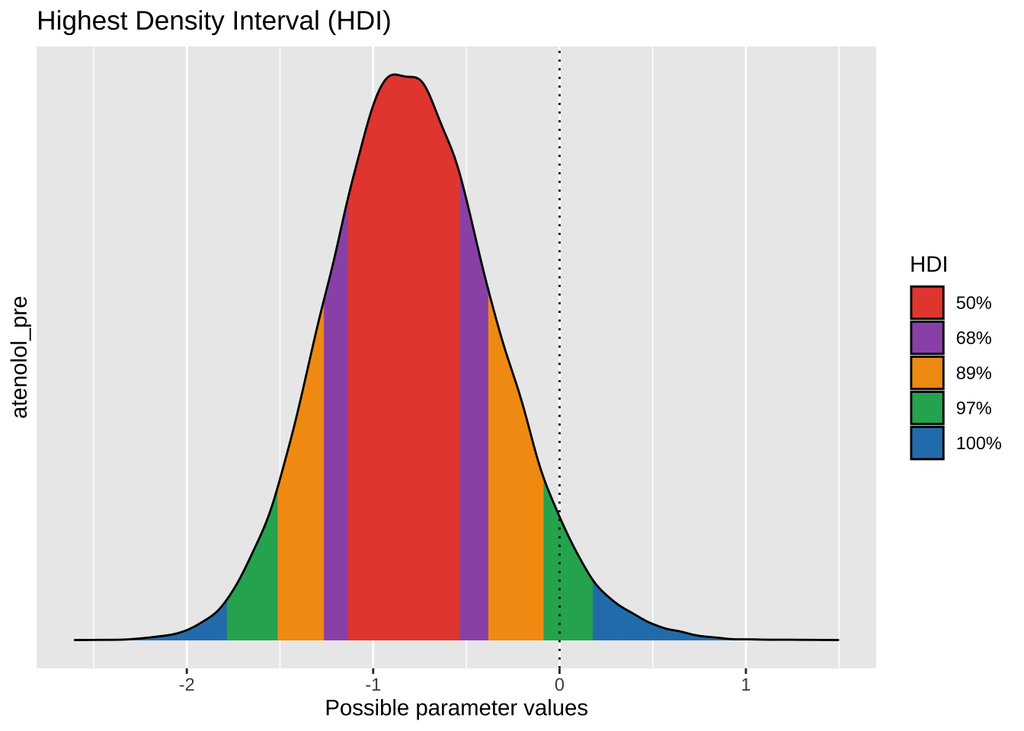

```r
hdi <- bayestestR::hdi(mod_aten_pre, ci = c(0.50, 0.68, 0.89, 0.97), parameters = "atenolol_pre")
plot(hdi)
```

## Get density plots for posterior distributons of beta parameters

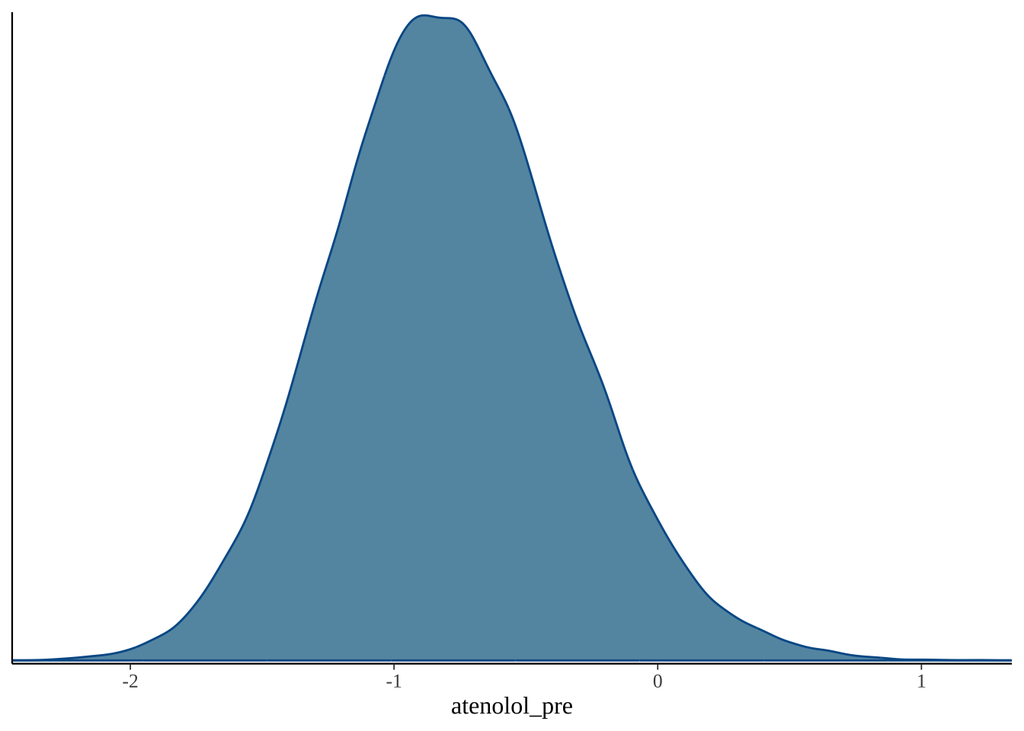

```r
mcmc_dens(posterior_mod_aten_pre,
  pars = c("atenolol_pre"))
```